# Orphanet Disorders of Glycosylation Study

### Topological analysis

#### MEAN

| Type | Clustering.coef | Diameter | Average.minimum.path | Number.of.nodes |
| --- | --- | --- | --- | --- |
| glycosylation_disorders | 0.4389486 | 5.00 | 2.579442 | 344.00 |
| shuffled_random_pairs | 0.1825884 | 10.48 | 3.927285 | 264.98 |
| vertexsort_random_pairs | 0.2264441 | 10.32 | 3.767519 | 263.80 |

#### STANDARD DEVIATION

| Type | Clustering.coef | Diameter | Average.minimum.path | Number.of.nodes |
| --- | --- | --- | --- | --- |
| glycosylation_disorders | NA | NA | NA | NA |
| shuffled_random_pairs | 0.0182357 | 1.034901 | 0.1275178 | 8.634270 |
| vertexsort_random_pairs | 0.0172227 | 1.168289 | 0.1425556 | 9.089128 |

**Table 3**: Topological Analysis results from the different Pairs Lists.

## Step 3: Tripartite network to obtain phenotype-function pairs

In this step we will get phenotype-genes pairs. Through a functional assignment of these genes we can get phenotype-function pairs.

**Table 4** Tripartite results general summary.

| Metric | Value |
| --- | --- |
| Number_of_phen2gene_pairs | 149836 |
| Number_of_HPO_with_genes | 6941 |
| Number_of_genes | 3178 |
| Number_of_phen2gene_pairs_HyI_2 | 54371 |
| Number_of_HPO_HyI_2 | 6907 |
| Number_of_genes_HyI_2 | 3155 |
| glycosylation_phenotypes_with_genes_HyI_2 | 342 |
| glycosylation_genes_HyI_2 | 1195 |
| Phenotypes_with_KEGG_0.05 | 5335 |
| Total_KEGG_terms_0.05 | 336 |
| Glycosylation_phenotypes_with_KEGG_0.05 | 294 |
| Glycosylation_KEGG_0.05 | 248 |
| Phenotypes_with_Reactome_0.05 | 6120 |
| Total_Reactome_terms_0.05 | 1549 |
| Glycosylation_phenotypes_with_Reactome_0.05 | 319 |
| Glycosylation_Reactome_0.05 | 1007 |
| Phenotypes_with_MF_0.05 | 6286 |
| Total_MF_terms_0.05 | 1209 |
| Glycosylation_phenotypes_with_MF_0.05 | 310 |
| Glycosylation_MF_0.05 | 759 |
| Phenotypes_with_CC_0.05 | 5653 |
| Total_CC_terms_0.05 | 726 |
| Glycosylation_phenotypes_with_CC_0.05 | 227 |
| Glycosylation_CC_0.05 | 513 |
| Phenotypes_with_BP_0.05 | 6558 |
| Total_BP_terms_0.05 | 6262 |
| Glycosylation_phenotypes_with_BP_0.05 | 328 |
| Glycosylation_BP_0.05 | 4267 |

## Step 4: Linkcomm Cluster Analysis

**Figure 3** Cluster analysis summary.

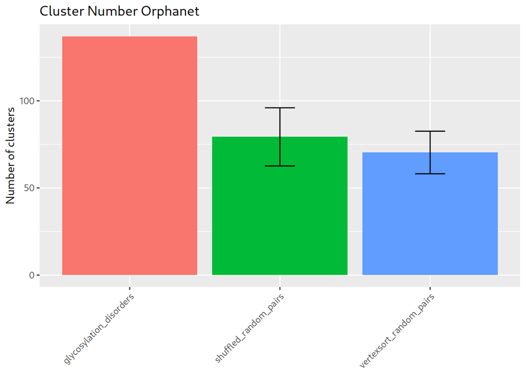

**Table 5** Cluster analysis summary.

| Type | Cluster Number |
| --- | --- |
| glycosylation_disorders | 137 ± NA |
| shuffled_random_pairs | 79.3 ± 16.696 |
| vertexsort_random_pairs | 70.34 ± 12.222 |

#### Functional Coherent Clusters Linkcomm

**Figure 4** Functional coherent clusters.

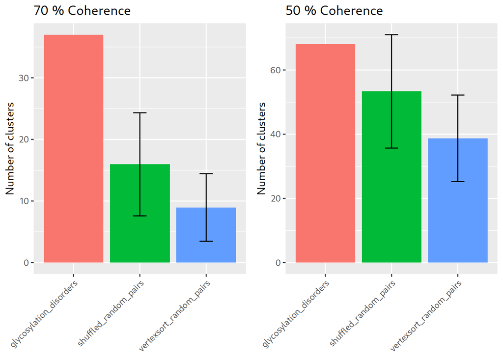

**Table 6** Functional coherent clusters summary.

| Type | Cluster with 70 coherence_0.05 | Cluster with 50 coherence_0.05 |
| --- | --- | --- |
| glycosylation_disorders | 37 ± NA | 68 ± NA |
| shuffled_random_pairs | 15.96 ± 8.367 | 53.34 ± 17.661 |
| vertexsort_random_pairs | 8.96 ± 5.488 | 38.72 ± 13.477 |

**Figure 5** Functional coherent clusters without GO.

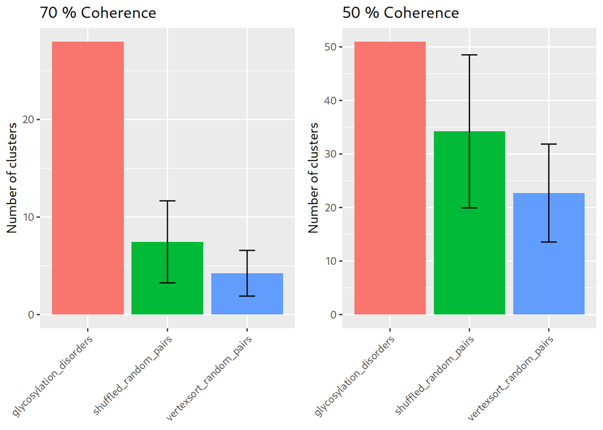

**Table 7** Functional coherent clusters summary.

| Type | Cluster with 70 coherence_0.05 | Cluster with 50 coherence_0.05 |
| --- | --- | --- |
| glycosylation_disorders | 28 ± NA | 51 ± NA |
| shuffled_random_pairs | 7.46 ± 4.205 | 34.22 ± 14.288 |
| vertexsort_random_pairs | 4.24 ± 2.344 | 22.7 ± 9.146 |

#### GO Biological Process

**Figure 6** Functional coherent clusters GO Biological Process.

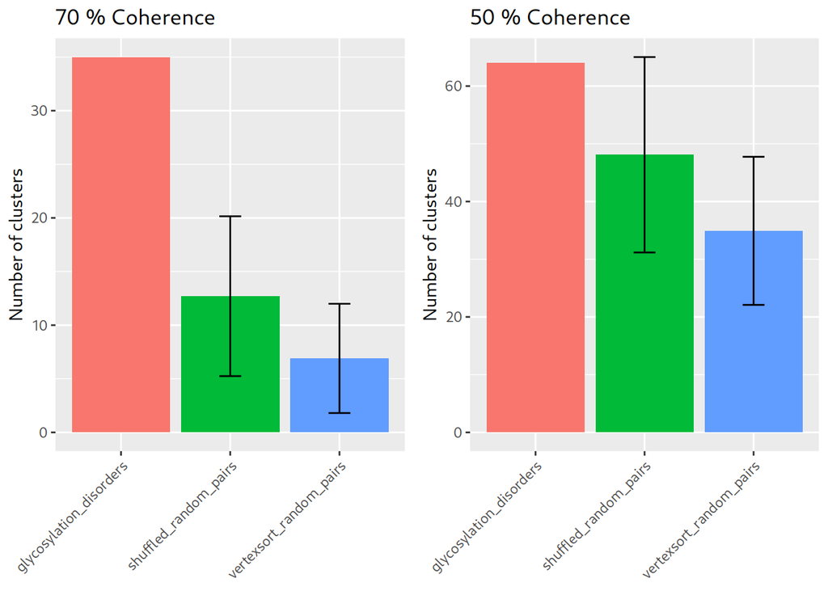

**Table 8** Functional coherent GO BP clusters summary.

| Type | Cluster with 70 coherence 0.05 BP | Cluster with 50 coherence 0.05 BP |
| --- | --- | --- |
| glycosylation_disorders | 35 ± NA | 64 ± NA |
| shuffled_random_pairs | 12.7 ± 7.454 | 48.1 ± 16.926 |
| vertexsort_random_pairs | 6.9 ± 5.096 | 34.92 ± 12.83 |

#### GO Molecular Function

**Figure 7** Functional coherent clusters GO Molecular Function.

[figure not shown]

**Table 9** Functional coherent GO MF clusters summary.

| Type | Cluster with 70 coherence 0.05 MF | Cluster with 50 coherence 0.05 MF |
| --- | --- | --- |
| glycosylation_disorders | 20 ± NA | 44 ± NA |
| shuffled_random_pairs | 3.54 ± 2.557 | 25.14 ± 12.132 |
| vertexsort_random_pairs | 2.18 ± 1.662 | 15.64 ± 7.162 |

#### GO Cellular Component

**Figure 8** Functional coherent clusters GO Cellular Component.

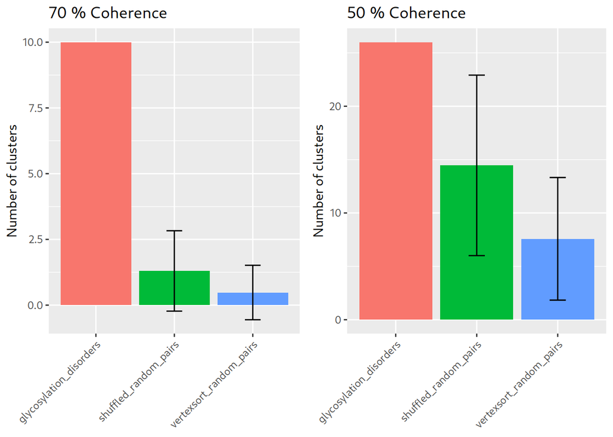

**Table 10** Functional coherent GO CC clusters summary.

| Type | Cluster with 70 coherence 0.05 CC | Cluster with 50 coherence 0.05 CC |
| --- | --- | --- |
| glycosylation_disorders | 10 ± NA | 26 ± NA |
| shuffled_random_pairs | 1.3 ± 1.529 | 14.46 ± 8.454 |
| vertexsort_random_pairs | 0.48 ± 1.035 | 7.58 ± 5.743 |

#### KEGG

**Figure 9** Functional coherent clusters KEGG.

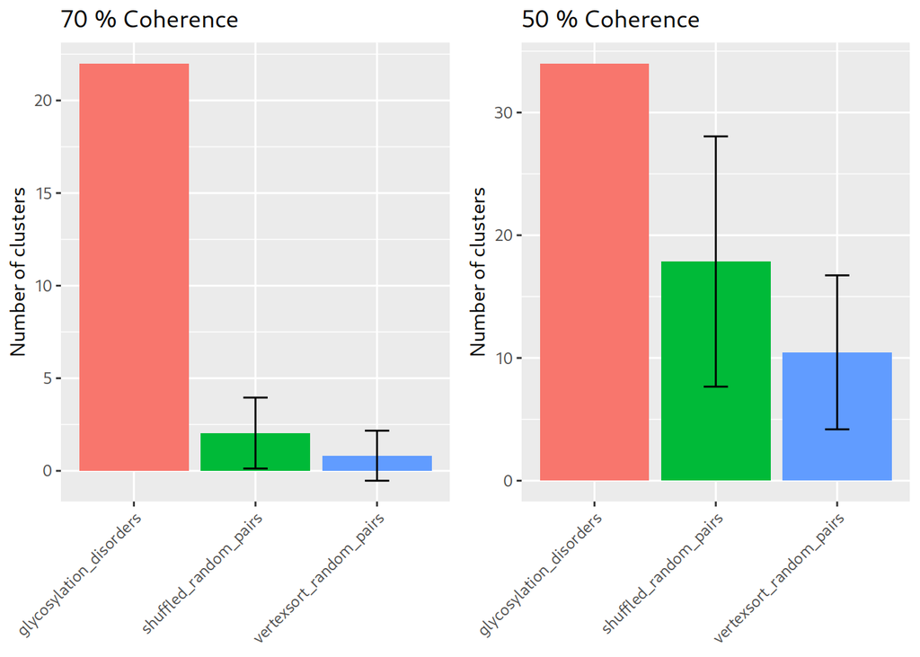

**Table 11** Functional coherent KEGG clusters summary.

[output not shown]

#### Reactome

**Figure 10** Functional coherent clusters Reactome.

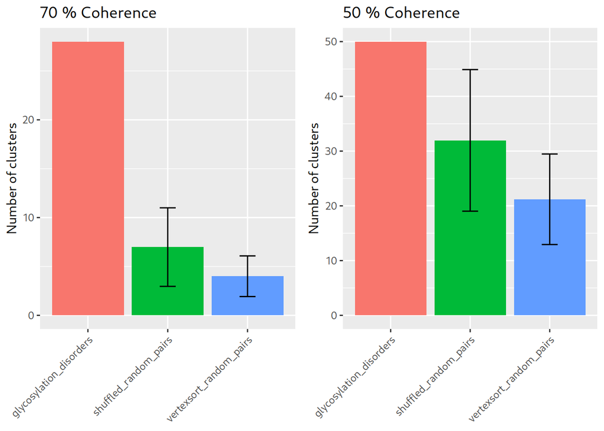

**Table 12** Functional coherent Reactome clusters summary.

| Type | Cluster with 70 coherence 0.05 Reactome | Cluster with 50 coherence 0.05 Reactome |
| --- | --- | --- |
| glycosylation_disorders | 28 ± NA | 50 ± NA |
| shuffled_random_pairs | 6.98 ± 4.018 | 31.96 ± 12.935 |
| vertexsort_random_pairs | 4 ± 2.08 | 21.2 ± 8.268 |